#ESSOUNAINI SOUFIANE

Summary:

I tried to do some exploratory data analysis on the Titanic data and to predict the survivors of the Ship using neural network.

```r
gender<-read.csv("gender_submission.csv")
class(gender$Survived)
```

```
## [1] "integer"
```

```r
train<-read.csv("train.csv")
train$survived<-as.numeric(train$Survived)
sum(train$Survived)/891
```

```
## [1] 0.3838384
```

```r
test<-read.csv("test.csv")
head(train)
```

```
##   PassengerId Survived Pclass
## 1           1        0      3
## 2           2        1      1
## 3           3        1      3
## 4           4        1      1
## 5           5        0      3
## 6           6        0      3
##                                                  Name    Sex Age SibSp Parch
## 1                             Braund, Mr. Owen Harris   male  22     1     0
## 2 Cumings, Mrs. John Bradley (Florence Briggs Thayer) female  38     1     0
## 3                              Heikkinen, Miss. Laina female  26     0     0
## 4        Futrelle, Mrs. Jacques Heath (Lily May Peel) female  35     1     0
## 5                            Allen, Mr. William Henry   male  35     0     0
## 6                                    Moran, Mr. James   male  NA     0     0
##             Ticket    Fare Cabin Embarked survived
## 1        A/5 21171  7.2500              S        0
## 2         PC 17599 71.2833   C85        C        1
## 3 STON/O2. 3101282  7.9250              S        1
## 4           113803 53.1000  C123        S        1
## 5           373450  8.0500              S        0
## 6           330877  8.4583              Q        0
```

```r
head(test)
```

```
##   PassengerId Pclass                                         Name    Sex  Age
## 1         892      3                             Kelly, Mr. James   male 34.5
## 2         893      3             Wilkes, Mrs. James (Ellen Needs) female 47.0
## 3         894      2                    Myles, Mr. Thomas Francis   male 62.0
## 4         895      3                             Wirz, Mr. Albert   male 27.0
## 5         896      3 Hirvonen, Mrs. Alexander (Helga E Lindqvist) female 22.0
## 6         897      3                   Svensson, Mr. Johan Cervin   male 14.0
##   SibSp Parch  Ticket    Fare Cabin Embarked
## 1     0     0  330911  7.8292              Q
## 2     1     0  363272  7.0000              S
## 3     0     0  240276  9.6875              Q
## 4     0     0  315154  8.6625              S
## 5     1     1 3101298 12.2875              S
## 6     0     0    7538  9.2250              S
```

```r
train1<-train[c(-2,-13)]
datas<-rbind(train1,test)
head(datas)
```

```
##   PassengerId Pclass                                                Name    Sex
## 1           1      3                             Braund, Mr. Owen Harris   male
## 2           2      1 Cumings, Mrs. John Bradley (Florence Briggs Thayer) female
## 3           3      3                              Heikkinen, Miss. Laina female
## 4           4      1        Futrelle, Mrs. Jacques Heath (Lily May Peel) female
## 5           5      3                            Allen, Mr. William Henry   male
## 6           6      3                                    Moran, Mr. James   male
##   Age SibSp Parch           Ticket    Fare Cabin Embarked
## 1  22     1     0        A/5 21171  7.2500              S
## 2  38     1     0         PC 17599 71.2833   C85        C
## 3  26     0     0 STON/O2. 3101282  7.9250              S
## 4  35     1     0           113803 53.1000  C123        S
## 5  35     0     0           373450  8.0500              S
## 6  NA     0     0           330877  8.4583              Q
```

```r
data3<-train %>%
        group_by(Sex) %>%
                summarise(somme=sum(Survived),na.rm=TRUE) %>%
        select(Sex,somme)
```

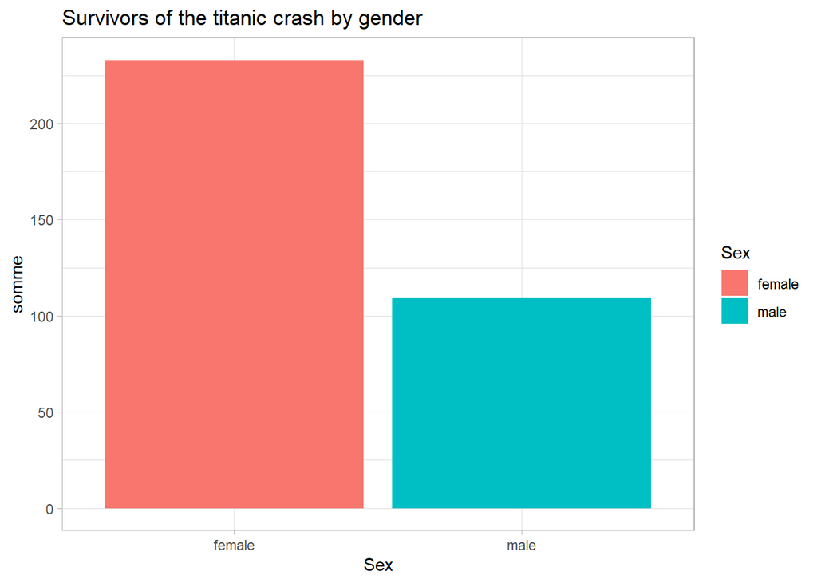

```r
g<-ggplot(data3,aes(x=Sex,y=somme))
g+geom_bar(stat="identity",aes(fill=Sex)) +theme_light()+labs(title = "Survivors of the titanic crash by gender",xlab="Sex",ylab="Total")
```

That’s totally understandable.They rescued women and babies first like we have all seen in the movie.

```r
data4<-train %>%
        group_by(Pclass) %>%
                summarise(Survivors=sum(Survived),na.rm=TRUE) %>%
        select(Pclass,Survivors)
```

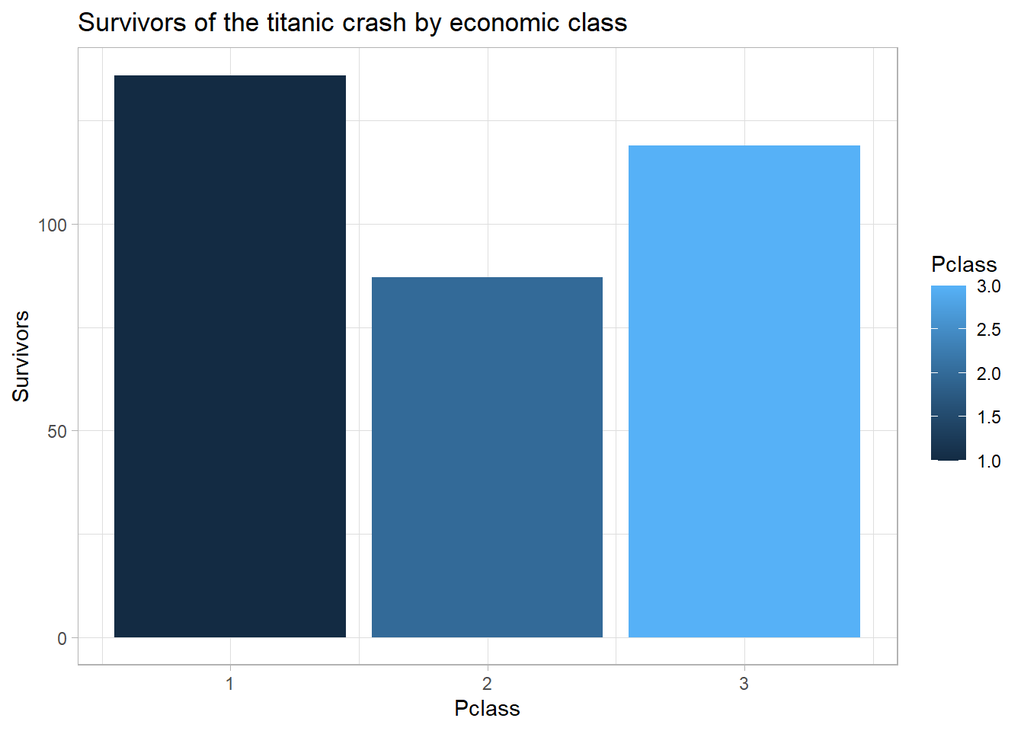

```r
g<-ggplot(data4,aes(x=Pclass,y=Survivors))
g+geom_bar(stat="identity",aes(fill=Pclass)) +theme_light()+labs(title = "Survivors of the titanic crash by economic class",xlab="Class",ylab="Survivors")
```

Like we see in the plot.People who were in the first class were more likely to survive the incident.

```r
par(mfrow=c(1,3))
data5<-train %>%
        group_by(Pclass,Sex) %>%
                summarise(Survivors=sum(Survived),na.rm=TRUE) %>%
        select(Sex,Pclass,Survivors)
data51<-data5[1:2,]
data52<-data5[3:4,]
data53<-data5[5:6,]
head(data5)
```

```
## # A tibble: 6 x 3
## # Groups:   Pclass [3]
##   Sex    Pclass Survivors
##   <fct>   <int>     <int>
## 1 female      1        91
## 2 male        1        45
## 3 female      2        70
## 4 male        2        17
## 5 female      3        72
## 6 male        3        47
```

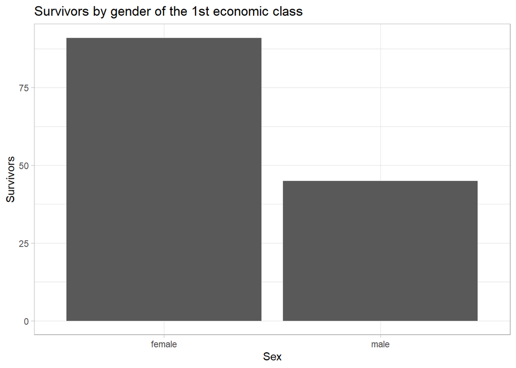

```r
g<-ggplot(data51,aes(x=Sex,y=Survivors))
g+geom_bar(stat="identity") +theme_light()+labs(title="Survivors by gender of the 1st economic class")
```

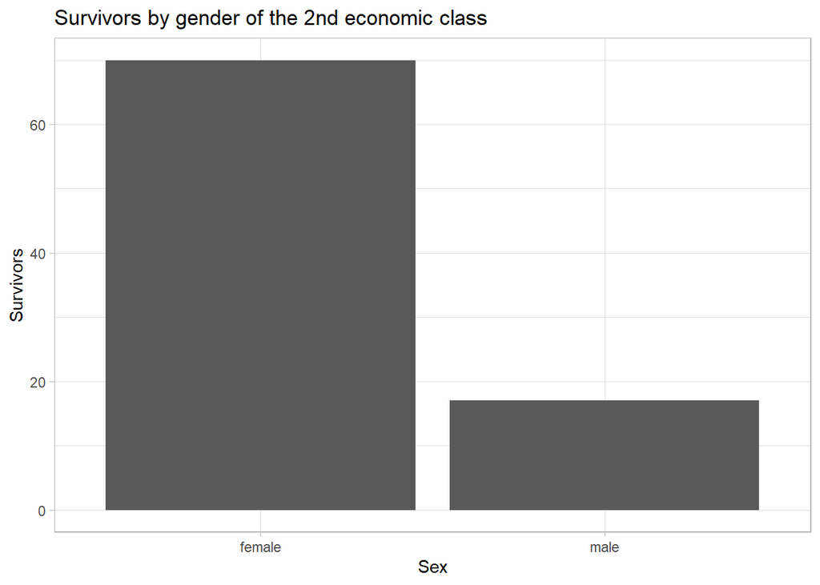

```r
g1<-ggplot(data52,aes(x=Sex,y=Survivors))
g1+geom_bar(stat="identity") +theme_light()+labs(title="Survivors by gender of the 2nd economic class")
```

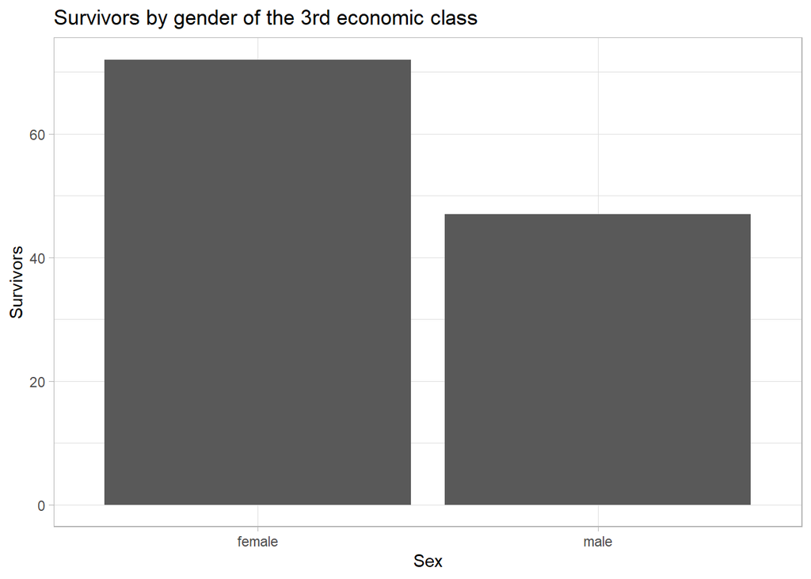

```r
g2<-ggplot(data53,aes(x=Sex,y=Survivors))
g2+geom_bar(stat="identity") +theme_light()+labs(title="Survivors by gender of the 3rd economic class")
```

```r
Looking_for_jack <- subset(train,Name=="Dawson,Mr. Jack")
head(Looking_for_jack)
```

```
##  [1] PassengerId Survived    Pclass      Name        Sex         Age
##  [7] SibSp       Parch       Ticket      Fare        Cabin       Embarked
## [13] survived
## <0 rows> (or 0-length row.names)
```

Just for fun: Like you see, we couldn’t find any information about Jack Dawson (The character played by Leonardo Dicaprio in the movie “Titanic”)

```r
# Data Partition
set.seed(222)
levels(train$Sex)<-c(1,0)
levels(test$Sex)<-c(1,0)
head(train)
```

```
##   PassengerId Survived Pclass
## 1           1        0      3
## 2           2        1      1
## 3           3        1      3
## 4           4        1      1
## 5           5        0      3
## 6           6        0      3
##                                                  Name Sex Age SibSp Parch
## 1                             Braund, Mr. Owen Harris   0  22     1     0
## 2 Cumings, Mrs. John Bradley (Florence Briggs Thayer)   1  38     1     0
## 3                              Heikkinen, Miss. Laina   1  26     0     0
## 4        Futrelle, Mrs. Jacques Heath (Lily May Peel)   1  35     1     0
## 5                            Allen, Mr. William Henry   0  35     0     0
## 6                                    Moran, Mr. James   0  NA     0     0
##             Ticket    Fare Cabin Embarked survived
## 1        A/5 21171  7.2500              S        0
## 2         PC 17599 71.2833   C85        C        1
## 3 STON/O2. 3101282  7.9250              S        1
## 4           113803 53.1000  C123        S        1
## 5           373450  8.0500              S        0
## 6           330877  8.4583              Q        0
```

```r
head(test)
```

```
##   PassengerId Pclass                                         Name Sex  Age
## 1         892      3                             Kelly, Mr. James   0 34.5
## 2         893      3             Wilkes, Mrs. James (Ellen Needs)   1 47.0
## 3         894      2                    Myles, Mr. Thomas Francis   0 62.0
## 4         895      3                             Wirz, Mr. Albert   0 27.0
## 5         896      3 Hirvonen, Mrs. Alexander (Helga E Lindqvist)   1 22.0
## 6         897      3                   Svensson, Mr. Johan Cervin   0 14.0
##   SibSp Parch  Ticket    Fare Cabin Embarked
## 1     0     0  330911  7.8292              Q
## 2     1     0  363272  7.0000              S
## 3     0     0  240276  9.6875              Q
## 4     0     0  315154  8.6625              S
## 5     1     1 3101298 12.2875              S
## 6     0     0    7538  9.2250              S
```

```r
train$Sex<-as.numeric(train$Sex)
train$Age<-as.numeric(train$Age)
test$Sex<-as.numeric(test$Sex)
test$Age<-as.numeric(test$Age)
train$Age
```

[output not shown]

[output cut: 60 more lines]

```r
# Neural Networks
library(neuralnet)
```

```r
set.seed(333)
n <- neuralnet(Survived~Pclass+Sex,
               data = train,
               hidden = 5,
               err.fct = "ce",
               linear.output = FALSE)
plot(n)
```

[output not shown]

```r
# Prediction
output <- compute(n, train[,c(-2,-13)])
head(output$net.result)
```

```
##           [,1]
## [1,] 0.1354676
## [2,] 0.9682994
## [3,] 0.5002184
## [4,] 0.9682994
## [5,] 0.1354676
## [6,] 0.1354676
```

```r
head(train[c(-2,-13)])
```

```
##   PassengerId Pclass                                                Name Sex
## 1           1      3                             Braund, Mr. Owen Harris   2
## 2           2      1 Cumings, Mrs. John Bradley (Florence Briggs Thayer)   1
## 3           3      3                              Heikkinen, Miss. Laina   1
## 4           4      1        Futrelle, Mrs. Jacques Heath (Lily May Peel)   1
## 5           5      3                            Allen, Mr. William Henry   2
## 6           6      3                                    Moran, Mr. James   2
##   Age SibSp Parch           Ticket    Fare Cabin Embarked
## 1  22     1     0        A/5 21171  7.2500              S
## 2  38     1     0         PC 17599 71.2833   C85        C
## 3  26     0     0 STON/O2. 3101282  7.9250              S
## 4  35     1     0           113803 53.1000  C123        S
## 5  35     0     0           373450  8.0500              S
## 6  NA     0     0           330877  8.4583              Q
```

```r
# Confusion Matrix & Misclassification Error - training data
output <- compute(n, train[,c(-2,-13)])
p1 <- output$net.result
pred1 <- ifelse(p1>0.5, 1, 0)
tab1 <- table(pred1, train$survived)
tab1
```

```
##
## pred1   0   1
##     0 468 109
##     1  81 233
```

```r
1-sum(diag(tab1))/sum(tab1)
```

```
## [1] 0.2132435
```

We have as accracy 0.786 which is not bad at all.

here are the predictions of our survivors :

```r
# Confusion Matrix & Misclassification Error - testing data
output <- compute(n,test)
p2 <- output$net.result
pred2 <- ifelse(p2>0.5, 1, 0)
tab2 <- table(pred2)
tab2
```

```
## pred2
##   0   1
## 266 152
```

```r
1-sum(diag(tab2))/sum(tab2)
```

```
## [1] 0
```